# Case Study - Machine Learning in R

8/29/2017

## Introduction

## Recall the Process of Data Science

[figure not shown]

## What We'll Do This Afternoon

- Introducing basic machine learning concepts and methods
- Form hypotheses through exploratory data analysis
- Continue wrangling the data for machine learning
- Implement some ML in R
  - Regression: predicting AirBnB prices
  - Classification: who survives the Titanic

## Why Machine Learning?

- Predictions
- Pattern recognition
- Interpretation
- Use predictions for prescriptions (tomorrow)
- Make some

[figure not shown]

  on [Kaggle](https://www.kaggle.com/competitions)

## Examples

- Risk prediction for cancer
- IBM Watson
- Image recognition
- Netflix recommender system
- …

## Machine Learning in R

- Many other languages can do ML (Matlab, Python, Julia, etc.)
- R bridges statistics and machine learning
- Powerful data manipulation and graphics tools
- Active community developing packages (11265+)!

[figure not shown]

## Types of machine learning

- *Supervised learning*: learn a function to map predictor variables (\(\mathbf{X}\)) to response variables (\(\mathbf{Y}\))
  - Linear models
  - SVM, CART, random forest
  - Neural networks
- *Unsupervised learning*: learn the structure of data points
  - Clustering (k-means, hierarchical clustering)
  - Anomaly detection
- *Semi-supervised learning*

## Model selection and evaluation

- Model evaluation
  - Perform on a separate set (train/test split)
  - Regression: \(R^2\), RMSE, MAE
  - Classification: Accuracy, confusion table, AUC
- Model selection
  - Cross validation (train/validation/test split)
  - Selection criterion

## Case Study - Regression

## Read in the data

- Read in the data and format the `price` as a numeric:

```r
library(tidyverse)
listings <- read_csv("../data/listings.csv")
listings <- listings %>%
  mutate(price = as.numeric(gsub("\\$|,","",price)))
```

## Exercise 1: Generating hypotheses

- Take 15 minutes to come up with your conceptual predictive models for the price, keep the following in mind:
  - Which factors influence price?
  - Should the relationship be linear?
  - Should variables be transformed?
  - Advanced: additional data to be joined on?
- Use visualization, data summary from the morning to explore

## Example visualization

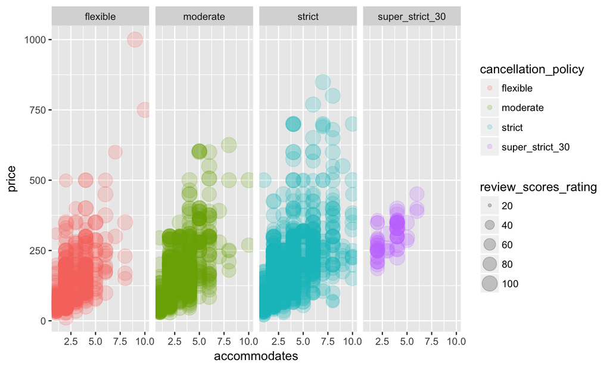

```r
listings_for_lm <-listings %>%
  filter(accommodates <= 10, price <= 1000)
listings_for_lm %>%
  ggplot() +
  aes(x=accommodates, y=price, color=cancellation_policy,
      size=review_scores_rating) +
  geom_point(alpha = 0.2) +
  facet_wrap(~cancellation_policy,ncol=4)
```

## First linear model

A linear model assumes the following structure: \[ y = \beta_0 + \beta_1 x_1 + \beta_2 x_2 + ... + \beta_p x_p + \epsilon \]  
Given data \(x_t\) and \(y_t\), it finds the \(\beta\) by solving the following problem: \[ \min_\beta \sum_{t=1}^n (y_t-x_t^T\beta)^2, \]  
which is also known as **ordinary least square** regression since it minimizes the sum of squared errors.

## First linear model, visualized

A single-variable linear fit of `price` on `accommodates`:

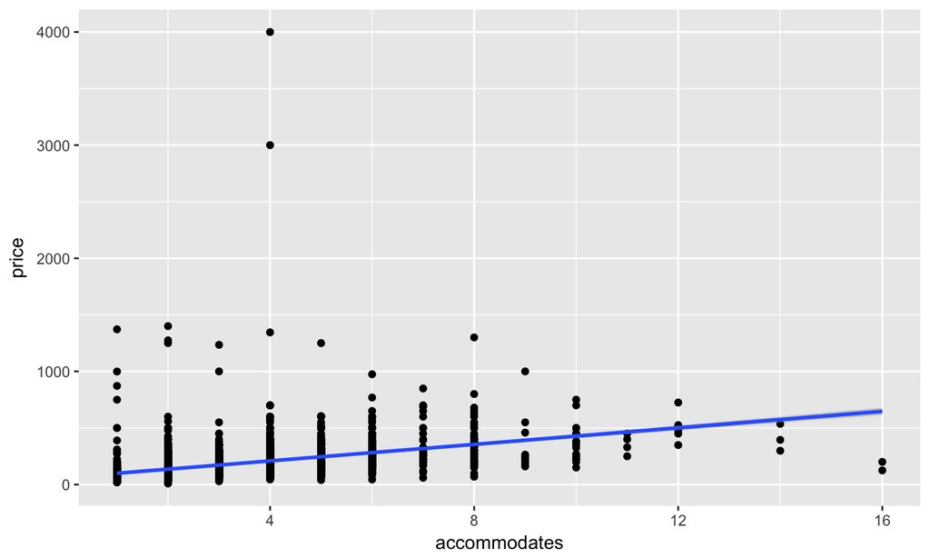

```r
listings %>%
  ggplot() +
  aes(x=accommodates, y=price) +
  geom_point() +
  geom_smooth(method="lm")
```

## First linear model in R

- Before running the model, recall we need to split data first:

```r
library(modelr)
set.seed(1)
listings_part <- listings_for_lm %>%
  resample_partition(c(train=0.7,test=0.3))
listings_part
```

```
## $train
## <resample [2,492 x 95]> 1, 2, 3, 5, 8, 9, 10, 11, 12, 13, ...
##
## $test
## <resample [1,069 x 95]> 4, 6, 7, 15, 17, 18, 20, 21, 25, 29, ...
```

- Now we can use the `lm()` command on the training:

```r
lm_price_by_acc <- lm(price ~ accommodates,data=listings_part$train)
```

## Look at model summary

```r
summary(lm_price_by_acc)
```

```
##
## Call:
## lm(formula = price ~ accommodates, data = listings_part$train)
##
## Residuals:
##     Min      1Q  Median      3Q     Max
## -291.47  -55.89  -18.61   41.25  906.54
##
## Coefficients:
##              Estimate Std. Error t value Pr(>|t|)
## (Intercept)    54.029      3.826   14.12   <2e-16 ***
## accommodates   38.431      1.118   34.38   <2e-16 ***
## ---
## Signif. codes:  0 '***' 0.001 '**' 0.01 '*' 0.05 '.' 0.1 ' ' 1
##
## Residual standard error: 92.4 on 2490 degrees of freedom
## Multiple R-squared:  0.3219, Adjusted R-squared:  0.3217
## F-statistic:  1182 on 1 and 2490 DF,  p-value: < 2.2e-16
```

## Exercise 2: Evaluating first model

- How would you visualize the model fit? Spend 10 minutes to come up with your visualizations
- Let's first run the following:

```r
listing_with_pred =  as.data.frame(listings_part$train) %>%
  add_predictions(lm_price_by_acc) %>%
  add_residuals(lm_price_by_acc,var="resid")
```

- Explanations:
  - `as.data.frame()` converts a resample object such as `listings_part$train` to a data frame
  - `add_predictions()` function from `modelr` package adds predicted values to a data frame
  - `add_residuals()` adds the model residual to the data frame

## Example from Exercise 2

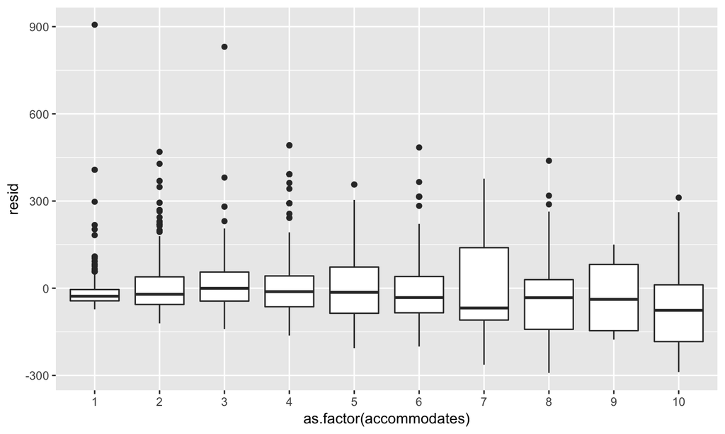

## Quantify first model performance

- Root Mean-squared Error (RMSE): \(\sqrt{\sum_{t=1}^n (\hat{y}_t - y_t)^2/n}\)
- Mean Absolute Error (MAE): \(\sum_{t=1}^n |\hat{y}_t - y_t|/n\)
- Coefficient of determination (\(R^2\)): \(1-\frac{\sum_{t=1}^n (\hat{y}_t - y_t)^2}{\sum_{t=1}^n (\bar{y}_t - y_t)^2}\)
  - \(\hat{y}_t\) is the predicted value for observation \(t\)
  - \(y_t\) is the actual value
  - \(\bar{y}_t\) is the mean value
- Pay attention to *in-sample* vs. *out-of-sample*!

## You can get them easily with `modelr`

```r
rmse(lm_price_by_acc,listings_part$test)
```

```
## [1] 94.04158
```

```r
mae(lm_price_by_acc,listings_part$test)
```

```
## [1] 64.47539
```

```r
rsquare(lm_price_by_acc,listings_part$test)
```

```
## [1] 0.3389596
```

## Summary of procedure

1. We asked the questions:
   1. How does listing price depend on the number of people it accommodates?
   2. How well does accommodation size predict price?
2. Since we were interested in prediction, we reserved part of our data as a test set.
3. We then chose to use a linear model to answer these questions, and found the corresponding function `lm()`, which takes:
   1. Data on the response and predictor variables, usually through a `formula` object
   2. Model parameters (in the case of `lm()`, we used all the default values)

## Summary of procedure

1. `R` then automatically found the "best" linear model by computing the least squares estimate, and returned a `lm` object, which was a list including information about
   1. Fitted coefficients
   2. Residuals
   3. Statistical significance
   4. …
2. With the `lm` object, we can add predictions and residuals to training and testing data, *diagnose* and *evaluate* model
3. If we see red flags during diagnosis, iterate to resolve the issue

## Add more variables

- We can build more interesting model formulas in `R`:
  - Predictors are separated with a `+`
  - Use `.` on the right-hand side to include all predictors in a given data frame
  - Use `.-x` to include all predictors except `x`
  - To include interactions between variables, use the `*` symbol. For example: `y ~ x + z + x*z`
  - To exclude the intercept term, include `-1` or `+0` on the right-hand side
- For more detailed info, see [documentation on R formula](https://stat.ethz.ch/R-manual/R-devel/library/stats/html/formula.html)

## Add more variables

- Inspect the "amenities" column. Need some data cleaning to make it useful!
- Run the cleaning code included in the script.
  - Using regular expressions and `grep/gsub` is very useful for cleaning strings. For more details, see [documentation on grep/gsub](https://stat.ethz.ch/R-manual/R-devel/library/base/html/grep.html)

## Exercise 3: Build your next model

- Work with your partner, build your next linear model with multiple variables.
  - Clean the data first if necessary (remove missing observations, etc.)
  - Remember the formula syntax
  - Use some of the amenity variables we just created
  - Consider interactions and transformation of variables
  - Don't forget to do the train/test split
- Generate model performance measures and compare with our first model
- Visualize data and results

## Example model

We use the following variables in the lm:

```
- accommodates
- property_type
- review_scores_rating
- neighbourhood_cleansed
- accommodates*room_type
- property_type*neighbourhood_cleansed
- review_scores_rating*neighbourhood_cleansed
- accommodates*review_scores_rating
- All columns created from the amenities column
```

How does the model performance look? Is there a big discrepancy between the *in-sample* and *out-of-sample* performance?

## Overfitting

Overfitting kills a seemingly good model!

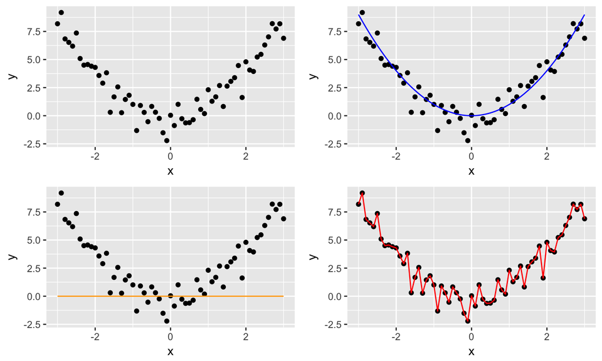

## LASSO

- When a model overfits, one solution is to add a term to the optimization problem
  - the term penalizes models that get too fancy without enough data
- Recall our classical linear regression looks like \[ \min_\beta \sum_{t=1}^n (y_t-x_t^T\beta)^2, \]
- Penalized regression looks like  
  \[ \min_\beta \sum_{t=1}^n (y_t-x_t^T\beta)^2 + \lambda ||\beta||. \]

## LASSO

- Two natural choices of norm are the Euclidean 1- and 2-norms:
  - 2-norm: "ridge regression"
  - 1-norm: "LASSO regression"
- Both types shrink all the elements of the unconstrained \(\beta\) vector towards zero, some more than others in a special way. LASSO shrinks the coefficients so that some are equal to zero.
- LASSO is incredibly popular, cited by 20,000+ papers!
- To do LASSO, we'll use the `glmnet` package.

## LASSO

- The syntax is a bit different from `lm()`, requiring the matrix `x` and vector `y` as inputs:

```r
library(glmnet)
x <- model.matrix(data=as.data.frame(listings_big_lm$train),
    ~ .-price + accommodates*room_type + property_type*neighbourhood_cleansed +
      review_scores_rating*neighbourhood_cleansed + accommodates*review_scores_rating)
y <- as.vector(as.data.frame(listings_big_lm$train)$price)
lasso_price <- glmnet(x,y)
```

## LASSO - interpret outputs

Running `glmnet` gives the results for a range of \(\lambda\) values. We can take a closer look at one:

```r
lasso_price$lambda[20]
```

```
## [1] 11.83448
```

```r
lasso_price$beta[which(lasso_price$beta[,20] != 0),20]
```

```
##                                 room_typePrivate room
##                                          -28.88130245
##                        neighbourhood_cleansedBack Bay
##                                            7.12540286
##                                        amenity_TVTRUE
##                                            0.96652016
##                  amenity_Free_Parking_on_PremisesTRUE
##                                           -5.01419276
##                          amenity_Air_ConditioningTRUE
##                                            4.31292591
##                          amenity_Indoor_FireplaceTRUE
##                                            2.91149473
##                                  amenity_Cable_TVTRUE
##                                            9.60928061
##                      amenity_Elevator_in_BuildingTRUE
##                                           18.09944292
##                    accommodates:room_typePrivate room
##                                          -10.02955100
##  property_typeHouse:neighbourhood_cleansedBeacon Hill
##                                           30.43384693
## review_scores_rating:neighbourhood_cleansedDorchester
##                                           -0.02463174
##                     accommodates:review_scores_rating
##                                            0.28281011
```

## Cross Validation

- We just trained many models, but should not choose one by comparing their performance in test set (why?)
- But we can do *cross-validation*
  - Only train on some of the training
  - Save the rest of training to evaluate (validation set)
  - A final test set to evaluate performance once we've settled on a model
- More economic way to use data: *k-fold* cross-validation
  - Divide the training data into groups called *folds*
  - For each fold repeat the train-validate procedure
  - Average the performance of each model on each fold and pick the best one.
- A common *resampling* method.

## Cross Validation, Illustrated

[figure not shown]

## Cross Validation in Action

The glmnet package has a very handy function called `cv.glmnet()` which does the entire process automatically.

- The relevant arguments are:
  - `x`, the matrix of predictors
  - `y`, the response variable
  - `nfolds`, the number of ways to split the training set (defaults to 10)
  - `type.measure`, the metric of prediction quality. It defaults to mean squared error, the square of RMSE, for linear regression

## Cross Validation in Action

```r
set.seed(1)
lasso_price_cv <- cv.glmnet(x,y)
lasso_price_cv$lambda.min
```

```
## [1] 1.268972
```

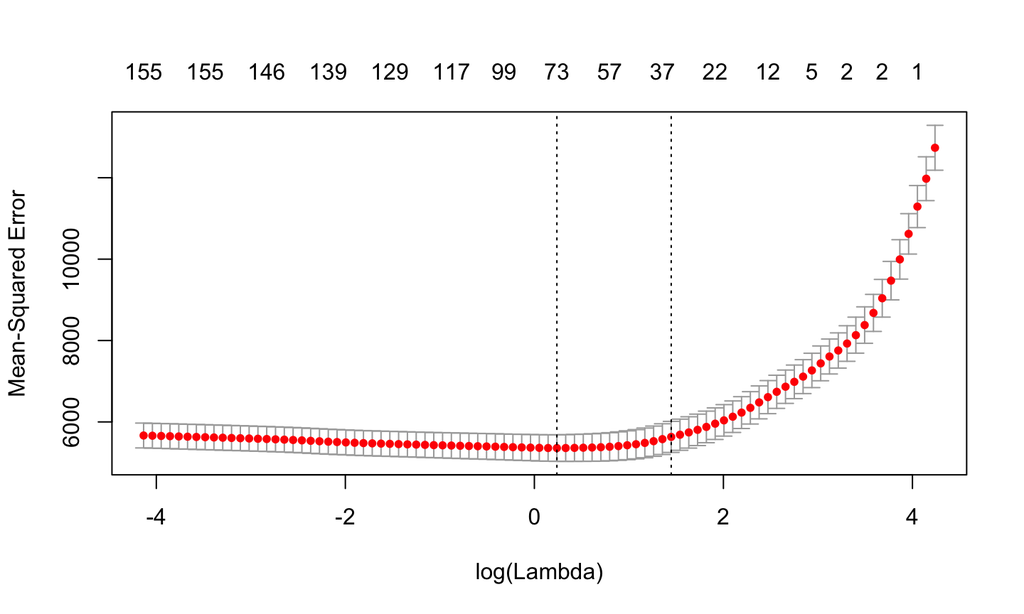

```r
plot.cv.glmnet(lasso_price_cv)
```

## Evaluate Cross-Validated Model

```r
lasso.pred <- predict.cv.glmnet(lasso_price_cv,newx=x_all, s="lambda.min")

listings_big %>%
  mutate(is_test = 1:nrow(listings_big) %in% listings_big_lm$test$idx,
         pred = lasso.pred) %>%
  group_by(is_test) %>%
  summarize(rmse = sqrt(1/length(price)*sum((price-pred)^2)))
```

```
## # A tibble: 2 x 2
##   is_test     rmse
##     <lgl>    <dbl>
## 1   FALSE 68.27384
## 2    TRUE 71.25230
```

Ain't bad, but still need better feature selection methods than LASSO. Stay tuned for sparse regressions in 15.680.

## Case Study - Classification

## Classification

- For classification, the \(y\) variable is a binary \(\{0, 1\}\) variable or a categorical variable.
  - Binary classification (cat vs. dog)
  - Multi-class classification (hand-written digit recognition)
- We are going to focus on binary classification today

## Logistic Regression

- Part of the class of generalized linear models (GLMs)
- These models take the linear fit and map it through a non-linear function.
- For logistic regression, it uses the logistic function \(f(x) = \frac{e^x}{1+e^x}\), which looks like this:

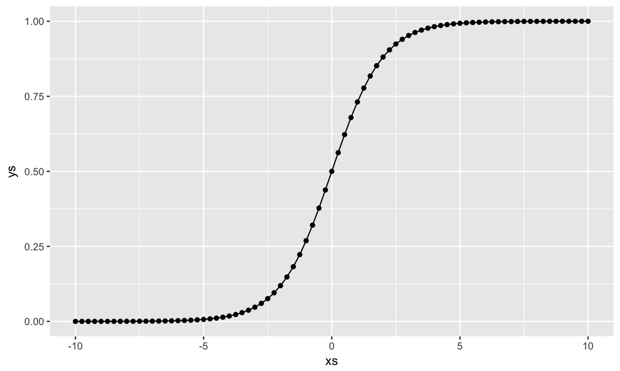

## Logistic Regression in R

The syntax is similar to linear regression, with `binomial` for the family parameter.

```
l.glm <- glm(y ~ x,family="binomial",data=mydata$train)
summary(l.glm)
```

## Titanic Survival

- Let's look at the titanic dataset:

```r
titanic <- read_csv("../data/titanic.csv")
```

|  | PassengerId | Survived | Pclass | Name | Sex | Age | SibSp | Parch | Ticket | Fare | Cabin | Embarked |
| --- | --- | --- | --- | --- | --- | --- | --- | --- | --- | --- | --- | --- |
| 1 | 1 | 0 | 3 | Braund, Mr. Owen Harris | male | 22 | 1 | 0 | A/5 21171 | 7.25 |  | S |
| 2 | 2 | 1 | 1 | Cumings, Mrs. John Bradley (Florence Briggs Thayer) | female | 38 | 1 | 0 | PC 17599 | 71.2833 | C85 | C |
| 3 | 3 | 1 | 3 | Heikkinen, Miss. Laina | female | 26 | 0 | 0 | STON/O2. 3101282 | 7.925 |  | S |
| 4 | 4 | 1 | 1 | Futrelle, Mrs. Jacques Heath (Lily May Peel) | female | 35 | 1 | 0 | 113803 | 53.1 | C123 | S |
| 5 | 5 | 0 | 3 | Allen, Mr. William Henry | male | 35 | 0 | 0 | 373450 | 8.05 |  | S |
| 6 | 6 | 0 | 3 | Moran, Mr. James | male |  | 0 | 0 | 330877 | 8.4583 |  | Q |
| 7 | 7 | 0 | 1 | McCarthy, Mr. Timothy J | male | 54 | 0 | 0 | 17463 | 51.8625 | E46 | S |
| 8 | 8 | 0 | 3 | Palsson, Master. Gosta Leonard | male | 2 | 3 | 1 | 349909 | 21.075 |  | S |
| 9 | 9 | 1 | 3 | Johnson, Mrs. Oscar W (Elisabeth Vilhelmina Berg) | female | 27 | 0 | 2 | 347742 | 11.1333 |  | S |
| 10 | 10 | 1 | 2 | Nasser, Mrs. Nicholas (Adele Achem) | female | 14 | 1 | 0 | 237736 | 30.0708 |  | C |

[output cut: 881 more lines]

## Exercise 4: Predict who survives

Take 20 minutes, working with your partner, construct a logistic regression model to predict `Survived` variables.

- Visualize data to generate hypothesis
- Transform data to engineer additional features
- Make sure to split training and testing. What do you think we should use to evaluate binary predictions?

## Example Solution

```
##
## Call:
## glm(formula = Survived ~ Sex + Pclass + SibSp + Parch + withFamily +
##     AgeGroup, family = "binomial", data = titanic_part$train)
##
## Deviance Residuals:
##     Min       1Q   Median       3Q      Max
## -2.5747  -0.6978  -0.4301   0.5938   2.6949
##
## Coefficients:
##                  Estimate Std. Error z value Pr(>|z|)
## (Intercept)       3.51301    0.49944   7.034 2.01e-12 ***
## Sexmale          -2.68542    0.24408 -11.002  < 2e-16 ***
## Pclass           -1.04575    0.14593  -7.166 7.71e-13 ***
## SibSp            -0.70164    0.17799  -3.942 8.08e-05 ***
## Parch            -0.42627    0.15715  -2.713  0.00668 **
## withFamily        0.95073    0.33283   2.856  0.00428 **
## AgeGroupYoung     1.41368    0.43055   3.283  0.00103 **
## AgeGroupMid-aged -0.02452    0.29231  -0.084  0.93315
## AgeGroupOld      -0.57335    0.40328  -1.422  0.15510
## ---
## Signif. codes:  0 '***' 0.001 '**' 0.01 '*' 0.05 '.' 0.1 ' ' 1
##
## (Dispersion parameter for binomial family taken to be 1)
##
##     Null deviance: 833.37  on 623  degrees of freedom
## Residual deviance: 552.72  on 615  degrees of freedom
## AIC: 570.72
##
## Number of Fisher Scoring iterations: 5
```

## Classification Evaluation

When we make a prediction (survived or not), it is often evaluated on:

- True positive rate
- False positive rate
- Accuracy

Since the output is a probability, we will need a threshold for the first metrics. Let's try using 0.5:

## Classification Evaluation

```r
l.pred <-predict(l.glm,newdata=titanic_part$test,type="response")
test_survived <- as.data.frame(titanic_part$test)$Survived
conf_table <- table(l.pred > 0.5, test_survived); conf_table
```

```
##        test_survived
##           0   1
##   FALSE 147  32
##   TRUE   20  68
```

```r
sum(diag(conf_table))/sum(conf_table)
```

```
## [1] 0.8052434
```

## Classification Evaluation

- But these metrics depend on the particular threshold.
- Area under the curve (AUC) measures the quality of all cutoffs simultaneously.
- Receiver operating characteristic Curve, or ROC:

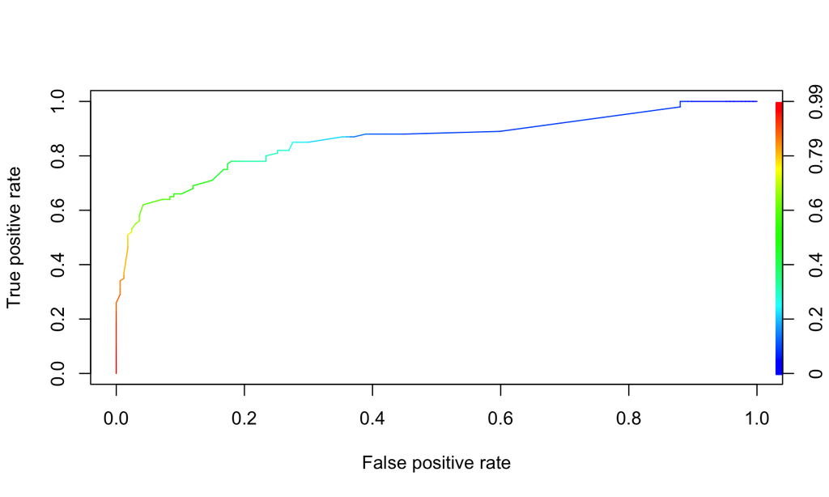

```r
library(ROCR)
pred_obj <-prediction(l.pred,test_survived) # Creating a prediction object for ROCR
perf <-performance(pred_obj,'tpr','fpr')
plot(perf, colorize = T)      # ROC curve
```

As the cutoff shrinks down from 1 to 0, the rate of total positives will increase.

## Classification Evaluation

To get the area under the curve, it is one line away:

```r
performance(pred_obj,'auc')@y.values
```

```
## [[1]]
## [1] 0.8553593
```

## Extensions

Similar to linear regression, there are many extensions to logistic regression:

- do LASSO logistic regression if there are many predictors, using the `glmnet` package
- add higher-order predictor terms via splines

> There are many other classification ML methods such as CART, random forest, optimal trees, neural networks that you will be learning in the machine learning course.

## Additional Resources

- [R for Data Science](http://r4ds.had.co.nz/), an online book on modeling via r’s `tidyverse` package.
- [The Elements of Statistical Learning](https://web.stanford.edu/~hastie/ElemStatLearn), by Hastie, Tibshirani, and Friedman
- MIT courses, including
- 15.680 (Machine Learning: Algorithms, Applications, and Computation),
- 15.071 (“The Analytics Edge”, an application and coding-based analytics course),
- 6.867 (EECS’s introductory Machine Learning course)
- 9.520 (A theory course about regularized machine learning methods)

## The End

Special thanks to Clark Pixton, Colin Pawlowski, and Jerry Kung for previous course materials.